# Unsupervised Learning: OnSports

**Marks: 60**

## Context

Fantasy sports are online gaming platforms where participants draft and manage virtual teams of real professional sports players. Based on the performance of the players in the real world, players are allotted points in the fantasy sports platform every match. The objective is to create the best possible team with a fixed budget to score maximum fantasy points, and users compete against each other over an entire sports league or season. Some of these fantasy sports require actual financial investments for participation, with the chances of winning monetary rewards as well as free matchday tickets on a periodic basis.

The fantasy sports market has seen tremendous growth over the past few years, with a valuation of \$18.6 billion in 2019. The football (soccer) segment led in terms of market share in 2019, with over 8 million participants worldwide, and is expected to retain its dominance over the next couple of years. Digitalization is one of the primary factors driving the growth of the fantasy sports market as it allows participants the opportunity to compete on a global level and test their skills. With an increase in smartphone usage and availability of fantasy sports apps, this market is expected to witness a globe surge and reach a \\$48.6 billion valuation by 2027.

## Objective

OnSports is a fantasy sports platform which has fantasy leagues for many different sports and has witnessed an increasing number of participants globally over the past 5 years. For each player, a price is set at the start, and the price keeps changing over time based on the performance of the players in the real world. With the new English Premier League season about to start, they have collected data of the past season and want to analyze it to determine the price of each player for the start of the new season. OnSports have hired you as a data scientist and asked you to conduct a cluster analysis to identify players of different potentials of each player based on previous season performance. This will help them understand the patterns in player performances and fantasy returns and decide the exact price to be set for each player for the upcoming football season.

### Data Dictionary

- Player_Name: Name of the player
- Club: Club in which the player plays
- Position: Position in which the player plays
- Goals_Scored: Number of goals scored by the player in the previous season
- Assists: Number of passes made by the player leading to goals in the previous season
- Total_Points: Total number of fantasy points scored by the player in the previous season
- Minutes: Number of minutes played by the player in the previous season
- Goals_Conceded: Number of goals conceded by the player in the previous season
- Creativity: A score, computed using a range of stats, that assesses player performance in terms of producing goalscoring opportunities for other players
- Influence: A score, computed using a range of stats, that evaluates a player's impact on a match, taking into account actions that could directly or indirectly affect the match outcome
- Threat: A score, computed using a range of stats, that gauges players who are most likely to score goals
- Bonus: Total bonus points received (The three best performing players in each match receive additional bonus points based on a score computed using a range of stats. 3 points are awarded to the highest scoring player, 2 to the second best, and 1 to the third.)
- Clean_Sheets: Number of matches without conceding a goal in the previous season

## Let's start coding!

### Importing necessary libraries

```python
# Libraries to help with reading and manipulating data
import numpy as np
import pandas as pd

# Libraries to help with data visualization
import matplotlib.pyplot as plt
import seaborn as sns

sns.set_theme(style='darkgrid')

# Removes the limit for the number of displayed columns
pd.set_option("display.max_columns", None)
# Sets the limit for the number of displayed rows
pd.set_option("display.max_rows", 200)

# to scale the data using z-score
from sklearn.preprocessing import StandardScaler

# to compute distances
from scipy.spatial.distance import cdist, pdist

# to perform k-means clustering and compute silhouette scores
from sklearn.cluster import KMeans
from sklearn.metrics import silhouette_score

# to visualize the elbow curve and silhouette scores
from yellowbrick.cluster import KElbowVisualizer, SilhouetteVisualizer

# to perform hierarchical clustering, compute cophenetic correlation, and create dendrograms
from sklearn.cluster import AgglomerativeClustering
from scipy.cluster.hierarchy import dendrogram, linkage, cophenet


# to suppress warnings
import warnings
warnings.filterwarnings("ignore")
```

```python
## Complete the code to import the data
data = pd.read_csv('fpl_data.csv')
```

```python
# checking shape of the data
print(f"There are {data.shape[0]} rows and {data.shape[1]} columns.") ## Complete the code to get the shape of data
```

```
There are 476 rows and 13 columns.
```

```python
# let's view a sample of the data
data.sample(n=10, random_state=1)
```

|  | Player_Name | Club | Position | Goals_Scored | Assists | Total_Points | Minutes | Goals_Conceded | Creativity | Influence | Threat | Bonus | Clean_Sheets |
| --- | --- | --- | --- | --- | --- | --- | --- | --- | --- | --- | --- | --- | --- |
| 441 | Mark Noble | West Ham United | Midfielder | 0 | 0 | 27 | 701 | 15 | 88.6 | 80.4 | 7 | 0 | 0 |
| 363 | Sean Longstaff | Newcastle United | Midfielder | 0 | 1 | 41 | 1405 | 26 | 182.8 | 179.2 | 148 | 1 | 2 |
| 31 | Anwar El Ghazi | Aston Villa | Midfielder | 10 | 0 | 111 | 1604 | 22 | 426.1 | 500.4 | 726 | 13 | 5 |
| 132 | Olivier Giroud | Chelsea | Forward | 4 | 0 | 47 | 740 | 5 | 112.0 | 161.4 | 403 | 6 | 4 |
| 90 | Chris Wood | Burnley | Forward | 12 | 3 | 138 | 2741 | 43 | 323.2 | 595.8 | 1129 | 16 | 9 |
| 249 | Vontae Daley-Campbell | Leicester City | Defender | 0 | 0 | 0 | 0 | 0 | 0.0 | 0.0 | 0 | 0 | 0 |
| 65 | Danny Welbeck | Brighton and Hove Albion | Forward | 6 | 4 | 89 | 1541 | 18 | 269.7 | 319.8 | 595 | 15 | 6 |
| 445 | Ryan Fredericks | West Ham United | Defender | 1 | 1 | 28 | 564 | 9 | 166.8 | 155.2 | 96 | 0 | 1 |
| 117 | Christian Pulisic | Chelsea | Midfielder | 4 | 3 | 82 | 1731 | 21 | 378.8 | 361.4 | 724 | 3 | 7 |
| 415 | Ryan Sessegnon | Tottenham Hotspurs | Defender | 0 | 0 | 0 | 0 | 0 | 0.0 | 0.0 | 0 | 0 | 0 |

```python
# checking the column names and datatypes
data.info()
```

```
<class 'pandas.core.frame.DataFrame'>
RangeIndex: 476 entries, 0 to 475
Data columns (total 13 columns):
 #   Column          Non-Null Count  Dtype
---  ------          --------------  -----
 0   Player_Name     476 non-null    object
 1   Club            476 non-null    object
 2   Position        476 non-null    object
 3   Goals_Scored    476 non-null    int64
 4   Assists         476 non-null    int64
 5   Total_Points    476 non-null    int64
 6   Minutes         476 non-null    int64
 7   Goals_Conceded  476 non-null    int64
 8   Creativity      476 non-null    float64
 9   Influence       476 non-null    float64
 10  Threat          476 non-null    int64
 11  Bonus           476 non-null    int64
 12  Clean_Sheets    476 non-null    int64
dtypes: float64(2), int64(8), object(3)
memory usage: 48.5+ KB
```

**Observation**

- There are no missing or null values
- Player_Name, Club and Position are object type data while the rest are numeric

```python
# copying the data to another variable to avoid any changes to original data
df = data.copy()
```

```python
# checking for duplicate values
df.duplicated().sum() ## Complete the code to get total number of duplicate values
```

```
0
```

```python
# checking for missing values in the data
df.isna().sum() ## Complete the code to check the missing values in the data
```

```
Player_Name       0
Club              0
Position          0
Goals_Scored      0
Assists           0
Total_Points      0
Minutes           0
Goals_Conceded    0
Creativity        0
Influence         0
Threat            0
Bonus             0
Clean_Sheets      0
dtype: int64
```

**Observation**

- There are no duplicated values*
- There is no missing data*

## Exploratory Data Analysis

**Let's check the statistical summary of the data.**

```python
df.describe(include='all').T
```

|  | count | unique | top | freq | mean | std | min | 25% | 50% | 75% | max |
| --- | --- | --- | --- | --- | --- | --- | --- | --- | --- | --- | --- |
| Player_Name | 476 | 476 | Alex Runnarsson | 1 | NaN | NaN | NaN | NaN | NaN | NaN | NaN |
| Club | 476 | 17 | Arsenal | 30 | NaN | NaN | NaN | NaN | NaN | NaN | NaN |
| Position | 476 | 4 | Midfielder | 195 | NaN | NaN | NaN | NaN | NaN | NaN | NaN |
| Goals_Scored | 476.0 | NaN | NaN | NaN | 1.907563 | 3.455562 | 0.0 | 0.0 | 0.5 | 2.0 | 23.0 |
| Assists | 476.0 | NaN | NaN | NaN | 1.752101 | 2.708563 | 0.0 | 0.0 | 0.0 | 2.0 | 14.0 |
| Total_Points | 476.0 | NaN | NaN | NaN | 58.516807 | 51.293559 | 0.0 | 10.0 | 48.0 | 94.25 | 244.0 |
| Minutes | 476.0 | NaN | NaN | NaN | 1336.909664 | 1073.773995 | 0.0 | 268.75 | 1269.5 | 2256.25 | 3420.0 |
| Goals_Conceded | 476.0 | NaN | NaN | NaN | 19.157563 | 15.946171 | 0.0 | 4.0 | 18.0 | 31.0 | 68.0 |
| Creativity | 476.0 | NaN | NaN | NaN | 195.97605 | 251.478541 | 0.0 | 8.3 | 96.95 | 296.95 | 1414.9 |
| Influence | 476.0 | NaN | NaN | NaN | 294.617647 | 267.779681 | 0.0 | 46.5 | 233.1 | 499.5 | 1318.2 |
| Threat | 476.0 | NaN | NaN | NaN | 224.962185 | 318.240377 | 0.0 | 5.75 | 104.5 | 298.25 | 1980.0 |
| Bonus | 476.0 | NaN | NaN | NaN | 4.718487 | 6.252625 | 0.0 | 0.0 | 2.0 | 7.0 | 40.0 |
| Clean_Sheets | 476.0 | NaN | NaN | NaN | 4.745798 | 4.394312 | 0.0 | 0.0 | 4.0 | 8.0 | 19.0 |

### Univariate analysis

```python
# function to plot a boxplot and a histogram along the same scale.


def histogram_boxplot(data, feature, figsize=(12, 7), kde=False, bins=None):
    """
    Boxplot and histogram combined

    data: dataframe
    feature: dataframe column
    figsize: size of figure (default (12,7))
    kde: whether to the show density curve (default False)
    bins: number of bins for histogram (default None)
    """
    f2, (ax_box2, ax_hist2) = plt.subplots(
        nrows=2,  # Number of rows of the subplot grid= 2
        sharex=True,  # x-axis will be shared among all subplots
        gridspec_kw={"height_ratios": (0.25, 0.75)},
        figsize=figsize,
    )  # creating the 2 subplots
    sns.boxplot(
        data=data, x=feature, ax=ax_box2, showmeans=True, color="violet"
    )  # boxplot will be created and a star will indicate the mean value of the column
    sns.histplot(
        data=data, x=feature, kde=kde, ax=ax_hist2, bins=bins, palette="winter"
    ) if bins else sns.histplot(
        data=data, x=feature, kde=kde, ax=ax_hist2
    )  # For histogram
    ax_hist2.axvline(
        data[feature].mean(), color="green", linestyle="--"
    )  # Add mean to the histogram
    ax_hist2.axvline(
        data[feature].median(), color="black", linestyle="-"
    )  # Add median to the histogram
```

**`Goals_Scored`**

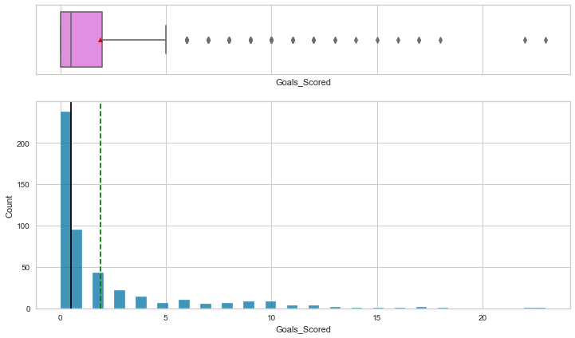

```python
histogram_boxplot(df, 'Goals_Scored')
```

**`Assists`**

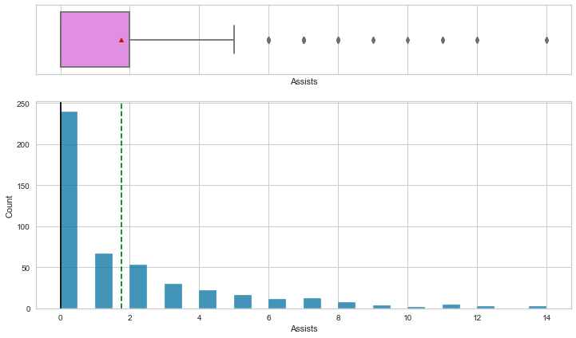

```python
histogram_boxplot(df, 'Assists')  ## Complete the code to create histogram_boxplot for 'Assists'
```

**`Goals_Conceded`**

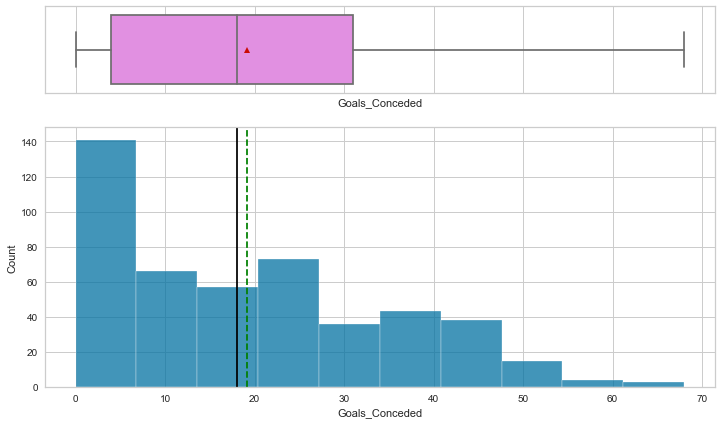

```python
histogram_boxplot(df, 'Goals_Conceded')  ## Complete the code to create histogram_boxplot for 'Goals_Conceded'
```

**`Clean_Sheets`**

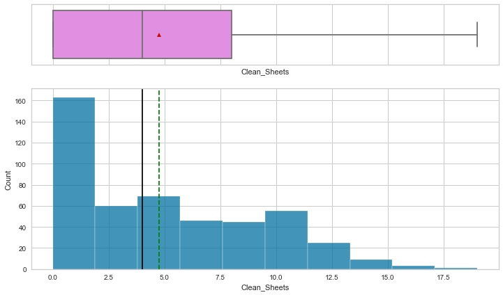

```python
histogram_boxplot(df, 'Clean_Sheets')  ## Complete the code to create histogram_boxplot for 'Clean_Sheets'
```

**`Minutes`**

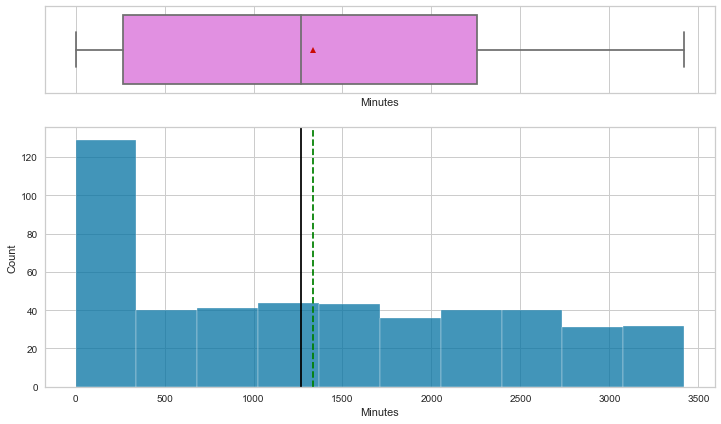

```python
histogram_boxplot(df, 'Minutes')  ## Complete the code to create histogram_boxplot for 'Minutes'
```

**`Total_Points`**

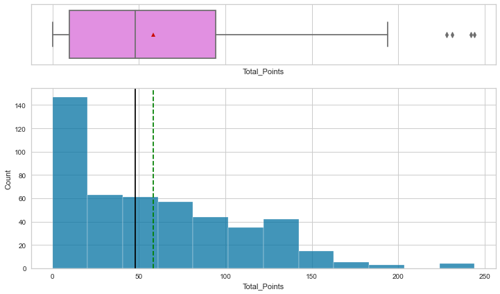

```python
histogram_boxplot(df, 'Total_Points')  ## Complete the code to create histogram_boxplot for 'Total_Points'
```

**`Creativity`**

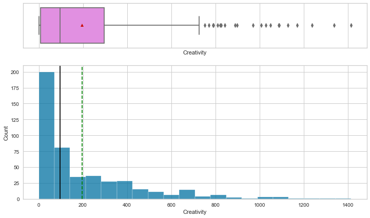

```python
histogram_boxplot(df, 'Creativity')  ## Complete the code to create histogram_boxplot for 'Creativity'
```

**`Influence`**

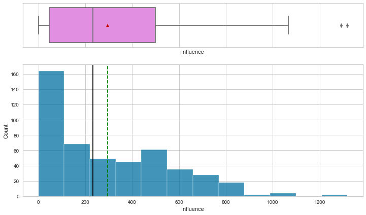

```python
histogram_boxplot(df, 'Influence')  ## Complete the code to create histogram_boxplot for 'Influence'
```

**`Threat`**

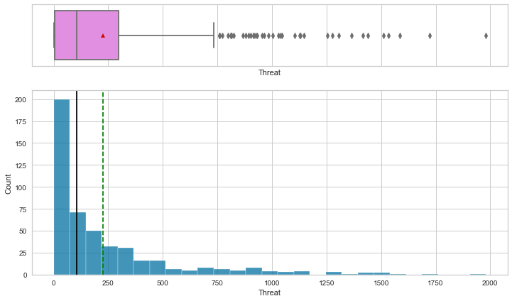

```python
histogram_boxplot(df, 'Threat')  ## Complete the code to create histogram_boxplot for 'Threat'
```

**`Bonus`**

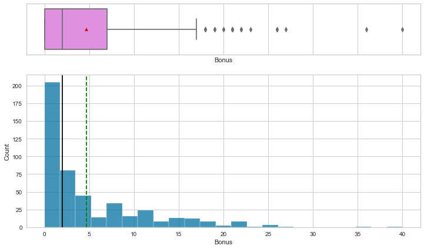

```python
histogram_boxplot(df, 'Bonus')  ## Complete the code to create histogram_boxplot for 'Bonus'
```

```python
# function to create labeled barplots


def labeled_barplot(data, feature, perc=False, n=None):
    """
    Barplot with percentage at the top

    data: dataframe
    feature: dataframe column
    perc: whether to display percentages instead of count (default is False)
    n: displays the top n category levels (default is None, i.e., display all levels)
    """

    total = len(data[feature])  # length of the column
    count = data[feature].nunique()
    if n is None:
        plt.figure(figsize=(count + 1, 5))
    else:
        plt.figure(figsize=(n + 1, 5))

    plt.xticks(rotation=90, fontsize=15)
    ax = sns.countplot(
        data=data,
        x=feature,
        palette="Paired",
        order=data[feature].value_counts().index[:n].sort_values(),
    )

    for p in ax.patches:
        if perc == True:
            label = "{:.1f}%".format(
                100 * p.get_height() / total
            )  # percentage of each class of the category
        else:
            label = p.get_height()  # count of each level of the category

        x = p.get_x() + p.get_width() / 2  # width of the plot
        y = p.get_height()  # height of the plot

        ax.annotate(
            label,
            (x, y),
            ha="center",
            va="center",
            size=12,
            xytext=(0, 5),
            textcoords="offset points",
        )  # annotate the percentage

    plt.show()  # show the plot
```

**`Club`**

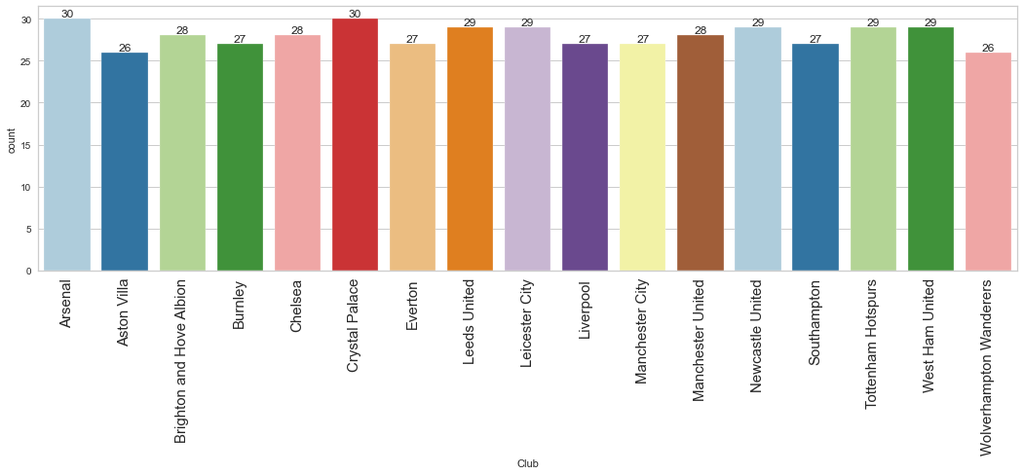

```python
labeled_barplot(df, 'Club')
```

**`Position`**

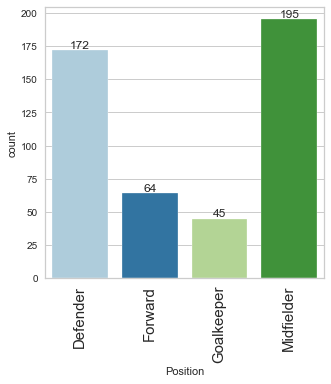

```python
labeled_barplot(df, 'Position')  ## Complete the code to create a labelled barplot for 'Position'
```

- There are 4 unique positions in the data set with Midfielder being the most prominent position at 195
- Defenders are the next most popular position at 172
- There are only 64 forwards and 45 goal keepers.

### Bivariate Analysis

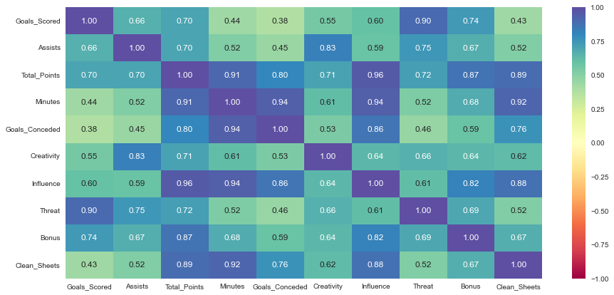

```python
# correlation check
cols_list = df.select_dtypes(include=np.number).columns.tolist()

plt.figure(figsize=(15, 7))
sns.heatmap(
    df[cols_list].corr(), annot=True, vmin=-1, vmax=1, fmt=".2f", cmap="Spectral"
)
plt.show()
```

- Number of `Goals` scored is highly correlated with `Assists, Total Points, Influence, Threat, Creativity and Bonus`
- This makes sense since the higher the 1) assists, 2) impact a player has on a match (Influence) and 3) the probability of a player scoring (`Threat`), the higher the number of goals scored and by extension bonus points will be awarded to the top three players.
- Additionally, the more `creative` a player is in creating goal scoring opportunities, the higher would be the `number of goals` scored.

**Let's check players from which team have scored the most fantasy points on average.**

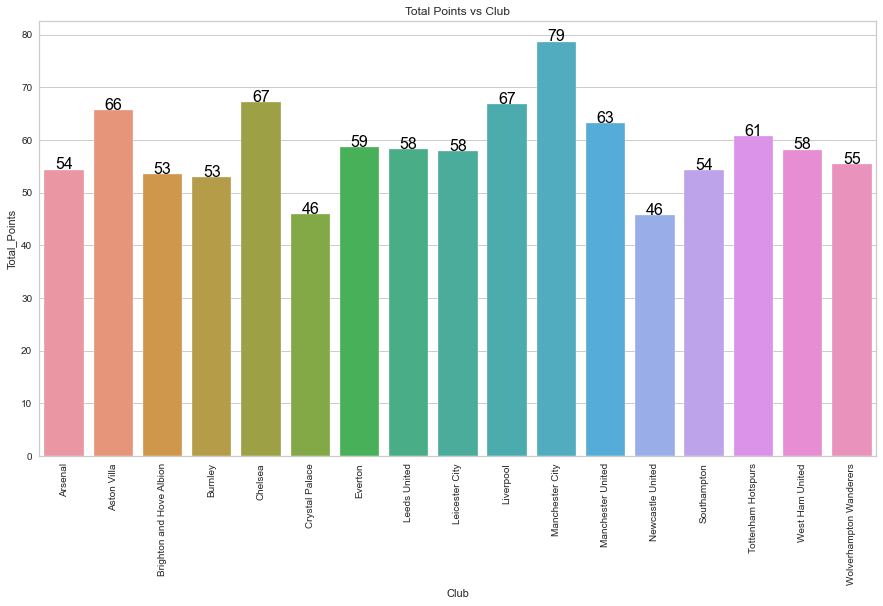

```python
plt.figure(figsize=(15,8))
graph = sns.barplot(y=df["Total_Points"], x=df["Club"], ci = False)## Complete the code to choose the right variables
graph.set_title("Total Points vs Club")
plt.xticks(rotation=90)
for p in graph.patches:
    graph.annotate(
        "%.0f" % p.get_height(),
        (p.get_x() + p.get_width() / 2.0, p.get_height()),
        ha="center",
        va="center",
        fontsize=16,
        color="black",
        xytext=(0, 5),
        textcoords="offset points",
    )
plt.show()
```

- Manchester City scored the highest `Total points` at 79
- Crystal Palace and Newcastle United had the lowest `Total Points` at 46

**We know that players in different positions have specific roles to play in a team. Let's check players in which positions tend to score more fantasy points on average.**

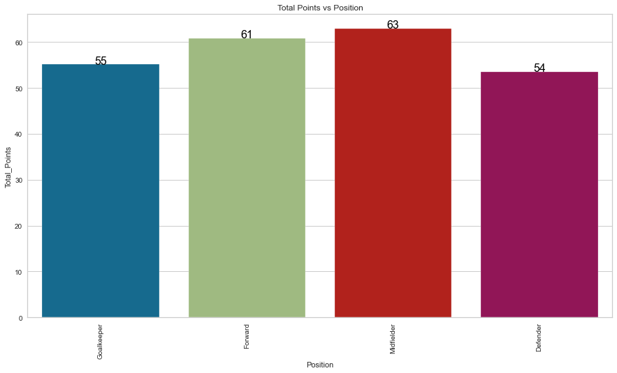

```python
plt.figure(figsize=(15,8))
graph = sns.barplot(y=df["Total_Points"], x=df["Position"], ci = False)## Complete the code to choose the right variables
graph.set_title("Total Points vs Position")
plt.xticks(rotation=90)
for p in graph.patches:
    graph.annotate(
        "%.0f" % p.get_height(),
        (p.get_x() + p.get_width() / 2.0, p.get_height()),
        ha="center",
        va="center",
        fontsize=16,
        color="black",
        xytext=(0, 5),
        textcoords="offset points",
    )
plt.show()
```

**To effectively utilize their squad depth, managers often rotate the squad to keep key players in shape for tougher games. Let's check the total number of minutes played, on average, across different positions.**

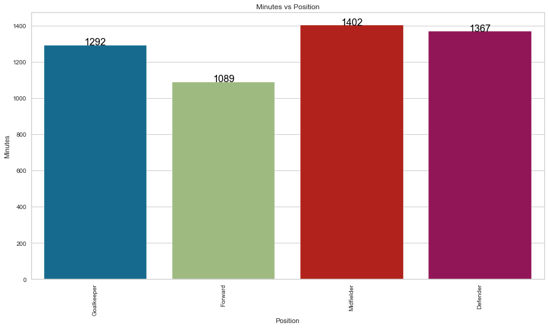

```python
plt.figure(figsize=(15,8))
graph = sns.barplot(y=df["Minutes"], x=df["Position"], ci = False)## Complete the code to choose the right variables
graph.set_title("Minutes vs Position")
plt.xticks(rotation=90)
for p in graph.patches:
    graph.annotate(
        "%.0f" % p.get_height(),
        (p.get_x() + p.get_width() / 2.0, p.get_height()),
        ha="center",
        va="center",
        fontsize=16,
        color="black",
        xytext=(0, 5),
        textcoords="offset points",
    )
plt.show()
```

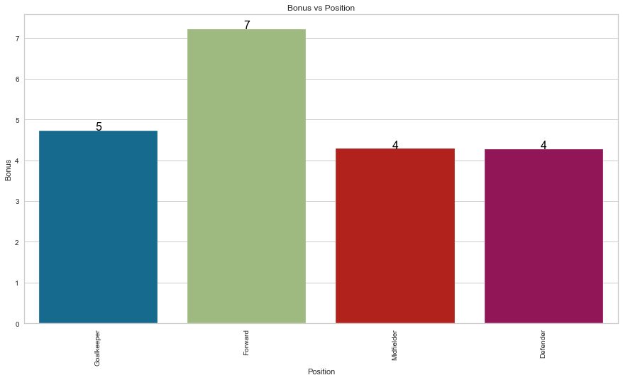

```python
plt.figure(figsize=(15,8))
graph = sns.barplot(y=df["Bonus"], x=df["Position"], ci = False)## Complete the code to choose the right variables
graph.set_title("Bonus vs Position")
plt.xticks(rotation=90)
for p in graph.patches:
    graph.annotate(
        "%.0f" % p.get_height(),
        (p.get_x() + p.get_width() / 2.0, p.get_height()),
        ha="center",
        va="center",
        fontsize=16,
        color="black",
        xytext=(0, 5),
        textcoords="offset points",
    )
plt.show()
```

**Let's see which players scored the most fantasy points last season for different positions of play.**

```python
pos_list = df.Position.unique().tolist()
best_df = pd.DataFrame()

for pos in pos_list:
    df_aux = df[df.Position == pos]
    best_df = best_df.append(df_aux[df_aux.Total_Points == df_aux.Total_Points.max()][['Player_Name', 'Club', 'Position', 'Total_Points']])

best_df
```

|  | Player_Name | Club | Position | Total_Points |
| --- | --- | --- | --- | --- |
| 36 | Emiliano Martinez | Aston Villa | Goalkeeper | 186 |
| 403 | Harry Kane | Tottenham Hotspurs | Forward | 242 |
| 315 | Bruno Fernandes | Manchester United | Midfielder | 244 |
| 223 | Stuart Dallas | Leeds United | Defender | 171 |

### Outlier Check

- Let's plot the boxplots of all numerical columns to check for outliers.

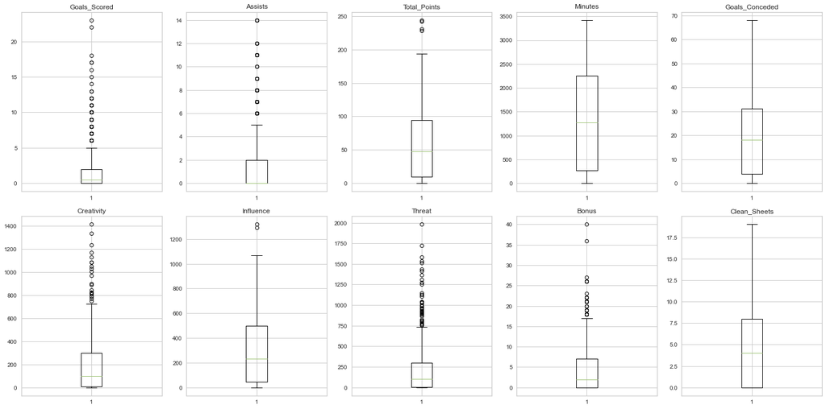

```python
plt.figure(figsize=(20, 10))

numeric_columns = df.select_dtypes(include=np.number).columns.tolist()

for i, variable in enumerate(numeric_columns):
    plt.subplot(2, 5, i + 1)
    plt.boxplot(df[variable], whis=1.5)
    plt.tight_layout()
    plt.title(variable)

plt.show()
```

### Scaling

- Let's scale the data before we proceed with clustering.

```python
# scaling the data before clustering
scaler = StandardScaler()
subset = df.iloc[:, 3:].copy()  ## Complete the code to get the scaled data
subset_scaled = scaler.fit_transform(subset)
```

```python
subset = df.iloc[:, 3:].copy() # (code to view only the numeric columns)
subset.head()# code to see the top 5 rows of the unscaled data
```

|  | Goals_Scored | Assists | Total_Points | Minutes | Goals_Conceded | Creativity | Influence | Threat | Bonus | Clean_Sheets |
| --- | --- | --- | --- | --- | --- | --- | --- | --- | --- | --- |
| 0 | 0 | 0 | 1 | 15 | 0 | 0.0 | 16.6 | 0 | 0 | 0 |
| 1 | 13 | 3 | 129 | 1916 | 21 | 307.4 | 602.4 | 797 | 21 | 7 |
| 2 | 0 | 0 | 131 | 3131 | 37 | 0.0 | 702.2 | 2 | 11 | 11 |
| 3 | 5 | 5 | 114 | 2554 | 31 | 650.6 | 493.0 | 984 | 8 | 8 |
| 4 | 0 | 3 | 36 | 751 | 10 | 169.4 | 171.8 | 77 | 3 | 2 |

```python
# creating a dataframe of the scaled data
subset_scaled_df = pd.DataFrame(subset_scaled, columns=subset.columns)
```

```python
subset_scaled_df.head() # code to see the top 5 rows of the scaled data
```

|  | Goals_Scored | Assists | Total_Points | Minutes | Goals_Conceded | Creativity | Influence | Threat | Bonus | Clean_Sheets |
| --- | --- | --- | --- | --- | --- | --- | --- | --- | --- | --- |
| 0 | -0.552608 | -0.647555 | -1.122506 | -1.232383 | -1.202653 | -0.780115 | -1.039325 | -0.707638 | -0.755435 | -1.081123 |
| 1 | 3.213401 | 0.461208 | 1.375560 | 0.539871 | 0.115663 | 0.443542 | 1.150596 | 1.799393 | 2.606688 | 0.513521 |
| 2 | -0.552608 | -0.647555 | 1.414592 | 1.672585 | 1.120094 | -0.780115 | 1.523682 | -0.701346 | 1.005677 | 1.424747 |
| 3 | 0.895857 | 1.200384 | 1.082818 | 1.134662 | 0.743432 | 1.809706 | 0.741621 | 2.387618 | 0.525374 | 0.741328 |
| 4 | -0.552608 | 0.461208 | -0.439441 | -0.546229 | -0.574884 | -0.105790 | -0.459134 | -0.465428 | -0.275132 | -0.625510 |

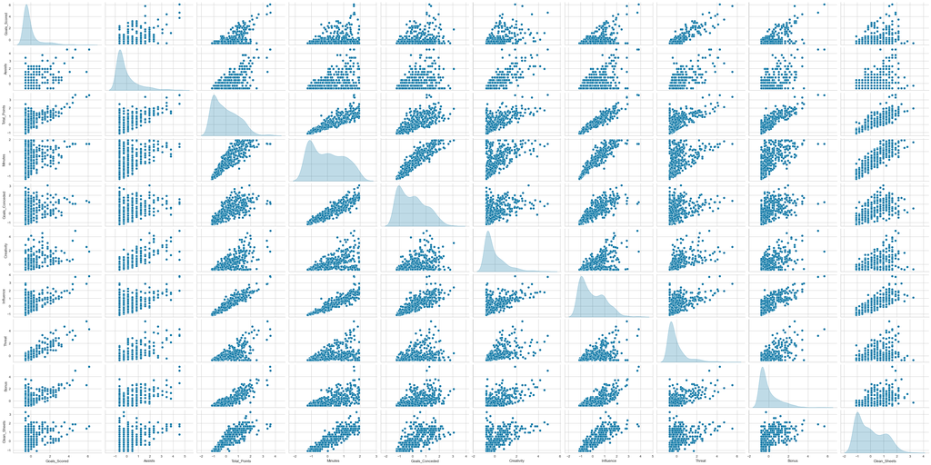

```python
#importing seaborn for statistical plots
sns.pairplot(subset_scaled_df, height=2,aspect=2 , diag_kind='kde')
```

**Observations**

- From the pair plot we can see that at minimum 3 clusters are required
- This can be seen by the number of peaks in the KDE plots
- We see that the independent variables are not truly independent since they have a degree of correlation between them
- This correlation can be reduced with linear feature extraction techniques such as PCA Analysis

## K-means Clustering

```python
k_means_df = subset_scaled_df.copy()
```

```
Number of Clusters: 1 	Average Distortion: 2.773037110097803
Number of Clusters: 2 	Average Distortion: 1.863573678589827
Number of Clusters: 3 	Average Distortion: 1.5612774038101604
Number of Clusters: 4 	Average Distortion: 1.3542782238901416
Number of Clusters: 5 	Average Distortion: 1.2931541699741689
Number of Clusters: 6 	Average Distortion: 1.225849543585495
Number of Clusters: 7 	Average Distortion: 1.16048401421345
Number of Clusters: 8 	Average Distortion: 1.109804758457438
Number of Clusters: 9 	Average Distortion: 1.0797310475776052
Number of Clusters: 10 	Average Distortion: 1.017436992641063
Number of Clusters: 11 	Average Distortion: 1.020874702026782
Number of Clusters: 12 	Average Distortion: 0.9850734409030882
Number of Clusters: 13 	Average Distortion: 0.9602766985773118
Number of Clusters: 14 	Average Distortion: 0.9413187781558084
```

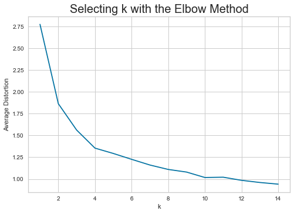

```python
clusters = range(1, 15)
meanDistortions = []

for k in clusters:
    model = KMeans(n_clusters=k, random_state=1)
    model.fit(subset_scaled_df)
    prediction = model.predict(k_means_df)
    distortion = (
        sum(np.min(cdist(k_means_df, model.cluster_centers_, "euclidean"), axis=1))
        / k_means_df.shape[0]
    )

    meanDistortions.append(distortion)

    print("Number of Clusters:", k, "\tAverage Distortion:", distortion)

plt.plot(clusters, meanDistortions, "bx-")
plt.xlabel("k")
plt.ylabel("Average Distortion")
plt.title("Selecting k with the Elbow Method", fontsize=20)
plt.show()
```

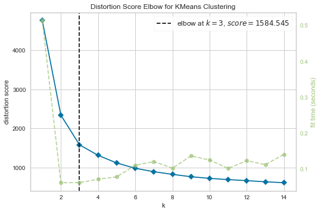

```python
model = KMeans(random_state=1)
visualizer = KElbowVisualizer(model, k=(1, 15), timings=True)
visualizer.fit(k_means_df)  # fit the data to the visualizer
visualizer.show()  # finalize and render figure
```

**Let's check the silhouette scores.**

```
For n_clusters = 2, the silhouette score is 0.48460299127690776)
For n_clusters = 3, the silhouette score is 0.4657385712264915)
For n_clusters = 4, the silhouette score is 0.4041321364385184)
For n_clusters = 5, the silhouette score is 0.41063881943698827)
For n_clusters = 6, the silhouette score is 0.41463610535548745)
For n_clusters = 7, the silhouette score is 0.3826908324316974)
For n_clusters = 8, the silhouette score is 0.3750329965069644)
For n_clusters = 9, the silhouette score is 0.3763672451125451)
For n_clusters = 10, the silhouette score is 0.3366262890546727)
For n_clusters = 11, the silhouette score is 0.3631675440508552)
For n_clusters = 12, the silhouette score is 0.3310947966019251)
For n_clusters = 13, the silhouette score is 0.3371354834021906)
For n_clusters = 14, the silhouette score is 0.3331138792029164)
```

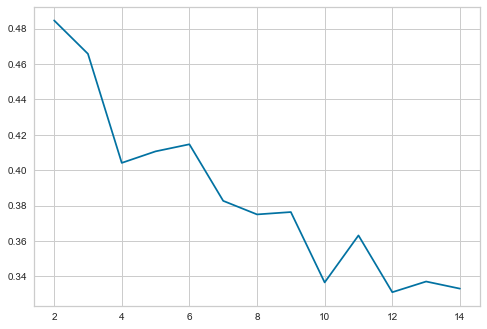

```python
sil_score = []
cluster_list = range(2, 15)
for n_clusters in cluster_list:
    clusterer = KMeans(n_clusters=n_clusters, random_state=1)
    preds = clusterer.fit_predict((subset_scaled_df))
    score = silhouette_score(k_means_df, preds)
    sil_score.append(score)
    print("For n_clusters = {}, the silhouette score is {})".format(n_clusters, score))

plt.plot(cluster_list, sil_score)
plt.show()
```

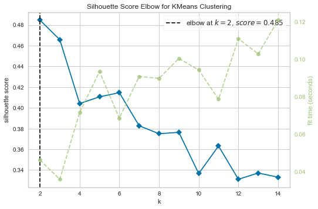

```python
model = KMeans(random_state=1)
visualizer = KElbowVisualizer(model, k=(2, 15), metric="silhouette", timings=True)
visualizer.fit(k_means_df)  # fit the data to the visualizer
visualizer.show()  # finalize and render figure
```

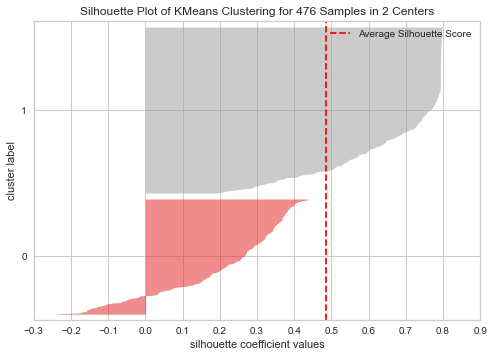

```python
# finding optimal no. of clusters with silhouette coefficients
visualizer = SilhouetteVisualizer(KMeans(2, random_state=1))  ## Complete the code to visualize the silhouette scores for certain number of clusters
visualizer.fit(k_means_df)
visualizer.show()
```

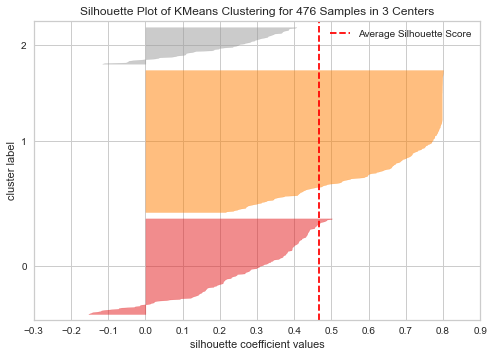

```python
# finding optimal no. of clusters with silhouette coefficients
visualizer = SilhouetteVisualizer(KMeans(3, random_state=1))  ## Complete the code to visualize the silhouette scores for certain number of clusters
visualizer.fit(k_means_df)
visualizer.show()
```

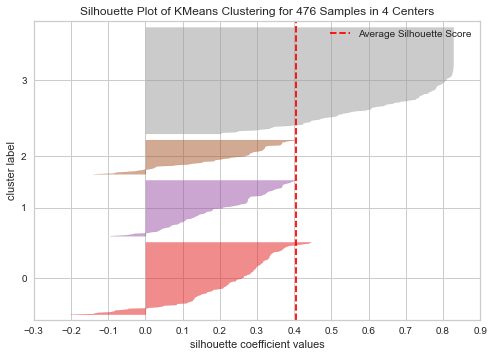

```python
# finding optimal no. of clusters with silhouette coefficients
visualizer = SilhouetteVisualizer(KMeans(4, random_state=1))  ## Complete the code to visualize the silhouette scores for certain number of clusters
visualizer.fit(k_means_df)
visualizer.show()
```

```python
# final K-means model
kmeans = KMeans(n_clusters=4, random_state=1)  ## Complete the code to choose the number of clusters
kmeans.fit(k_means_df)
```

```
KMeans(n_clusters=4, random_state=1)
```

```python
# creating a copy of the original data
df1 = df.copy()

# adding kmeans cluster labels to the original and scaled dataframes
k_means_df["KM_segments"] = kmeans.labels_
df1["KM_segments"] = kmeans.labels_
```

### Cluster Profiles

```python
km_cluster_profile = df1.groupby("KM_segments").mean()  ## Complete the code to groupby the cluster labels
```

```python
km_cluster_profile["count_in_each_segment"] = (
    df1.groupby("KM_segments")["Total_Points"].count().values  ## Complete the code to groupby the cluster labels
)
```

```python
km_cluster_profile.style.highlight_max(color="lightgreen", axis=0)
```

| KM_segments | Goals_Scored | Assists | Total_Points | Minutes | Goals_Conceded | Creativity | Influence | Threat | Bonus | Clean_Sheets | count_in_each_segment |
| --- | --- | --- | --- | --- | --- | --- | --- | --- | --- | --- | --- |
| 0 | 1.460938 | 1.601562 | 55.648438 | 1389.453125 | 20.554688 | 187.653125 | 270.037500 | 218.117188 | 3.312500 | 4.687500 | 128 |
| 1 | 1.363636 | 1.878788 | 103.525253 | 2670.555556 | 37.525253 | 265.671717 | 579.185859 | 199.636364 | 7.676768 | 10.020202 | 99 |
| 2 | 9.147541 | 6.639344 | 141.557377 | 2446.704918 | 33.344262 | 617.495082 | 659.324590 | 880.540984 | 16.147541 | 9.213115 | 61 |
| 3 | 0.148936 | 0.202128 | 9.824468 | 238.750000 | 3.930851 | 28.171809 | 43.164894 | 30.244681 | 0.409574 | 0.558511 | 188 |

```python
## Complete the code to print the players in each cluster
for cl in df1["KM_segments"].unique():
    print("In cluster {}, the following players are present:".format(cl))
    print(df1[df1["KM_segments"] == cl]["Player_Name"].unique())
    print()
```

```
In cluster 3, the following players are present:
['Alex Runnarsson' 'Cedric Soares' 'Edward Nketiah'
 'Gabriel Teodoro Martinelli Silva' 'Matt Macey' 'Miguel Azeez'
 'Pablo Mari' 'Reiss Nelson' 'Sead Kolasinac' 'Shkodran Mustafi'
 'Sokratis Papastathopoulos' 'William Saliba' 'Ahmed El Mohamady'
 'Carney Chukwuemeka' 'Conor Hourihane' 'Henri Lansbury' 'Jacob Ramsey'
 'Jaden Philogene-Bidace' 'Jose Peleteiro Romallo' 'Keinan Davis'
 'Kortney Hause' 'Marvelous Nakamba' 'Morgan Sanson' 'Orjan Nyland'
 'Wesley Moraes' 'Alireza Jahanbakhsh' 'Andi Zeqiri'
 'Bernardo Fernandes da Silva Junior' 'Davy Propper' 'Jakub Moder'
 'Jason Steele' 'Jayson Molumby' 'Jose Izquierdo' 'Percy Tau'
 'Reda Khadra' 'Anthony Driscoll-Glennon' 'Bailey Peacock-Farrell'
 'Dale Stephens' 'Jimmy Dunne' 'Joel Mumbongo' 'Josh Benson' 'Kevin Long'
 'Lewis Richardson' 'Phil Bardsley' 'Will Norris' 'Billy Gilmour'
 'Emerson Palmieri dos Santos' 'Faustino Anjorin' 'Fikayo Tomori'
 'Karlo Ziger' 'Kepa Arrizabalaga' 'Valentino Livramento'
 'Willy Caballero' 'Connor Wickham' 'Jack Butland' 'James McCarthy'
 'James Tomkins' 'Jean-Philippe Mateta' 'Mamadou Sakho' 'Martin Kelly'
 'Nathan Ferguson' 'Reece Hannam' 'Ryan Inniss' 'Sam Woods'
 'Stephen Henderson' 'Anthony Gordon' 'Bernard Caldeira Duarte'
 'Cenk Tosun' 'Fabian Delph' 'Joao Virginia' 'Jonjoe Kenny' 'Joshua King'
 'Moise Kean' 'Nathan Broadhead' 'Niels Nkounkou' 'Robin Olsen'
 'Adam Forshaw' 'Francisco Casilla' 'Gaetano Berardi'
 'Ian Carlo Poveda-Ocampo' 'Jack Jenkins' 'Jamie Shackleton'
 'Jay-Roy Grot' 'Jordan Stevens' 'Kamil Miazek' 'Leif Davis'
 'Mateusz Bogusz' 'Niall Huggins' 'Pablo Hernandez' 'Cengiz Under'
 'Christian Fuchs' 'Daniel Amartey' 'Demarai Gray' 'Filip Benkovic'
 'Hamza Choudhury' 'Islam Slimani' 'Luke Thomas' 'Sidnei Tavares'
 'Thakgalo Leshabela' 'Vontae Daley-Campbell' 'Wes Morgan'
 'Adrian Castillo' 'Alex Oxlade-Chamberlain' 'Caoimhin Kelleher'
 'Divock Origi' 'Joel Matip' 'Joseph Gomez' 'Naby Keita' 'Neco Williams'
 'Ozan Kabak' 'Rhys Williams' 'Virgil van Dijk' 'Xherdan Shaqiri'
 'Eric Garcia' 'Liam Delap' 'Luke Mbete' 'Nathan Ake' 'Nicolas Otamendi'
 'Scott Carson' 'Taylor Harwood-Bellis' 'Zack Steffen'
 'Alex Nicolao Telles' 'Amad Diallo' 'Anthony Elanga' 'Axel Tuanzebe'
 'Brandon Williams' 'Donny van de Beek' 'Hannibal Mejbri' 'Juan Mata'
 'Nathan Bishop' 'Odion Ighalo' 'Shola Shoretire' 'William Fish'
 'Andy Carroll' 'DeAndre Yedlin' 'Dwight Gayle' 'Elliot Anderson'
 'Florian Lejeune' 'Javier Manquillo' 'Kelland Watts' 'Matthew Longstaff'
 'Yoshinori Muto' 'Caleb Watts' "Daniel N'Lundulu" 'Fraser Forster'
```

[output cut: 80 more lines]

```
 'Thiago Alcantara' 'Aymeric Laporte' 'Benjamin Mendy'
 'Fernando Luiz Rosa' 'Ferran Torres' 'Kyle Walker' 'Oleksandr Zinchenko'
 'Sergio Aguero' 'Anthony Martial' 'Daniel James' 'Eric Bailly'
 'Nemanja Matic' 'Allan Saint-Maximin' 'Ciaran Clark' 'Emil Krafth'
 'Fabian Schar' 'Federico Fernandez' 'Isaac Hayden' 'Jacob Murphy'
 'Jamaal Lascelles' 'Jamal Lewis' 'Joelinton de Lira' 'Joseph Willock'
 'Martin Dubravka' 'Matt Ritchie' 'Paul Dummett' 'Ryan Fraser'
 'Sean Longstaff' 'Ibrahima Diallo' 'Jack Stephens' 'Moussa Djenepo'
 'Nathan Redmond' 'Oriol Romeu Vidal' 'Takumi Minamino' 'Theo Walcott'
 'Ben Davies' 'Davinson Sanchez' 'Giovani Lo Celso' 'Lucas Moura'
 'Matt Doherty' 'Moussa Sissoko' 'Serge Aurier' 'Steven Bergwijn'
 'Arthur Masuaku' 'Craig Dawson' 'Fabian Balbuena' 'Issa Diop'
 'Said Benrahma' 'Sebastian Haller' 'Daniel Castelo Podence' 'Fabio Silva'
 'Max Kilman' 'Raul Jimenez ' 'Rayan Ait Nouri' 'Willian Jose'
 'Willy Boly']
```

```python
df1.groupby(["KM_segments", "Position"])['Player_Name'].count()
```

```
KM_segments  Position
0            Defender      47
             Forward       16
             Goalkeeper     3
             Midfielder    62
1            Defender      50
             Goalkeeper    17
             Midfielder    32
2            Defender       5
             Forward       20
             Midfielder    36
3            Defender      70
             Forward       28
             Goalkeeper    25
             Midfielder    65
Name: Player_Name, dtype: int64
```

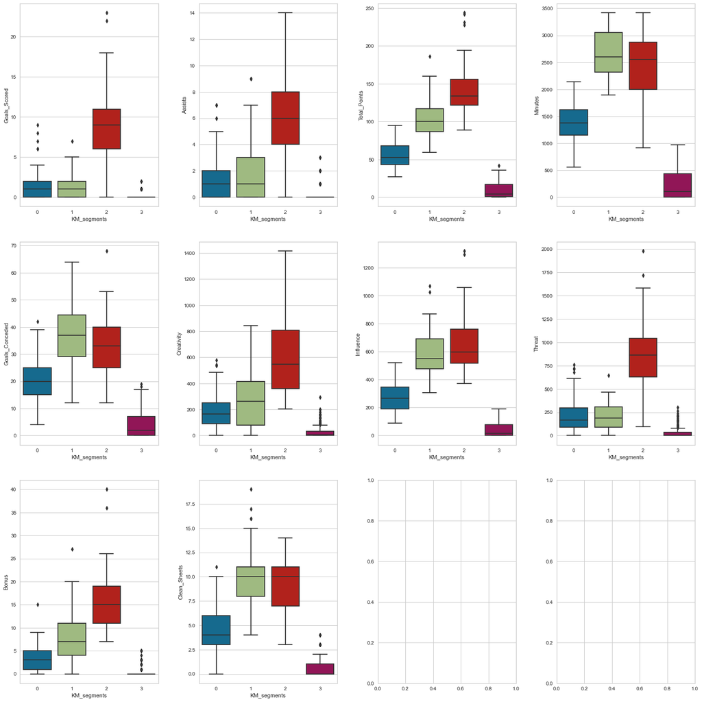

```python
fig, axes = plt.subplots(3, 4, figsize=(20, 20))
counter = 0

for ii in range(3):
    for jj in range(4):
        if counter < 10:
            sns.boxplot(
                ax=axes[ii][jj],
                data=df1,
                y=df1.columns[3+counter],
                x="KM_segments",
            )
            counter = counter + 1

fig.tight_layout(pad=3.0)
```

# Hierarchical Clustering

```python
hc_df = subset_scaled_df.copy()
```

```python
# list of distance metrics
distance_metrics = ["euclidean", "chebyshev", "mahalanobis", "cityblock"]

# list of linkage methods
linkage_methods = ["single", "complete", "average", "weighted"]

high_cophenet_corr = 0
high_dm_lm = [0, 0]

for dm in distance_metrics:
    for lm in linkage_methods:
        Z = linkage(hc_df, metric=dm, method=lm)
        c, coph_dists = cophenet(Z, pdist(hc_df))
        print(
            "Cophenetic correlation for {} distance and {} linkage is {}.".format(
                dm.capitalize(), lm, c
            )
        )
        if high_cophenet_corr < c:
            high_cophenet_corr = c
            high_dm_lm[0] = dm
            high_dm_lm[1] = lm

# printing the combination of distance metric and linkage method with the highest cophenetic correlation
print('*'*100)
print(
    "Highest cophenetic correlation is {}, which is obtained with {} distance and {} linkage.".format(
        high_cophenet_corr, high_dm_lm[0].capitalize(), high_dm_lm[1]
    )
)
```

```
Cophenetic correlation for Euclidean distance and single linkage is 0.8430175514228705.
Cophenetic correlation for Euclidean distance and complete linkage is 0.741204129226176.
Cophenetic correlation for Euclidean distance and average linkage is 0.8476499945585418.
Cophenetic correlation for Euclidean distance and weighted linkage is 0.862458135106748.
Cophenetic correlation for Chebyshev distance and single linkage is 0.8397660913391951.
Cophenetic correlation for Chebyshev distance and complete linkage is 0.8083029497725449.
Cophenetic correlation for Chebyshev distance and average linkage is 0.8590072179300738.
Cophenetic correlation for Chebyshev distance and weighted linkage is 0.8367206550474544.
Cophenetic correlation for Mahalanobis distance and single linkage is 0.8065008904132239.
Cophenetic correlation for Mahalanobis distance and complete linkage is 0.6583135946489036.
Cophenetic correlation for Mahalanobis distance and average linkage is 0.7747800632434048.
Cophenetic correlation for Mahalanobis distance and weighted linkage is 0.6486408054242746.
Cophenetic correlation for Cityblock distance and single linkage is 0.8299646528677203.
Cophenetic correlation for Cityblock distance and complete linkage is 0.8493041408810342.
Cophenetic correlation for Cityblock distance and average linkage is 0.8127162760037657.
Cophenetic correlation for Cityblock distance and weighted linkage is 0.8553115836932642.
Highest cophenetic correlation is 0.862458135106748, which is obtained with Euclidean distance and weighted linkage.
```

**Let's explore different linkage methods with Euclidean distance only.**

```python
# list of linkage methods
linkage_methods = ["single", "complete", "average", "centroid", "ward", "weighted"]

high_cophenet_corr = 0
high_dm_lm = [0, 0]

for lm in linkage_methods:
    Z = linkage(hc_df, metric="euclidean", method=lm)
    c, coph_dists = cophenet(Z, pdist(hc_df))
    print("Cophenetic correlation for {} linkage is {}.".format(lm, c))
    if high_cophenet_corr < c:
        high_cophenet_corr = c
        high_dm_lm[0] = "euclidean"
        high_dm_lm[1] = lm

# printing the combination of distance metric and linkage method with the highest cophenetic correlation
print('*'*100)
print(
    "Highest cophenetic correlation is {}, which is obtained with {} linkage.".format(
        high_cophenet_corr, high_dm_lm[1]
    )
)
```

```
Cophenetic correlation for single linkage is 0.8430175514228705.
Cophenetic correlation for complete linkage is 0.741204129226176.
Cophenetic correlation for average linkage is 0.8476499945585418.
Cophenetic correlation for centroid linkage is 0.8068296032280463.
Cophenetic correlation for ward linkage is 0.5777738445861551.
Cophenetic correlation for weighted linkage is 0.862458135106748.
Highest cophenetic correlation is 0.862458135106748, which is obtained with weighted linkage.
```

**Let's view the dendrograms for the different linkage methods with Euclidean distance only.**

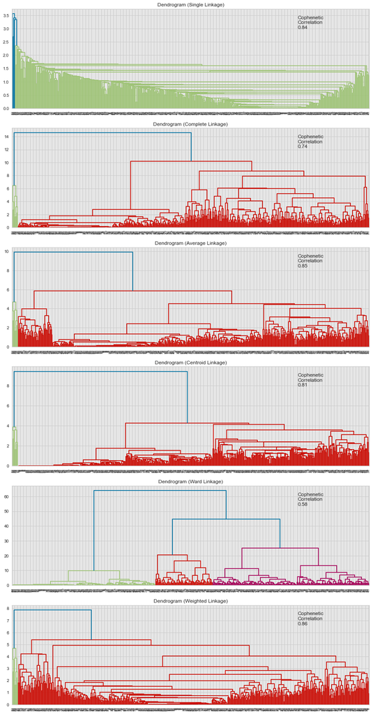

```python
# list of linkage methods
linkage_methods = ["single", "complete", "average", "centroid", "ward", "weighted"]

# lists to save results of cophenetic correlation calculation
compare_cols = ["Linkage", "Cophenetic Coefficient"]
compare = []

# to create a subplot image
fig, axs = plt.subplots(len(linkage_methods), 1, figsize=(15, 30))

# We will enumerate through the list of linkage methods above
# For each linkage method, we will plot the dendrogram and calculate the cophenetic correlation
for i, method in enumerate(linkage_methods):
    Z = linkage(hc_df, metric="euclidean", method=method)

    dendrogram(Z, ax=axs[i])
    axs[i].set_title(f"Dendrogram ({method.capitalize()} Linkage)")

    coph_corr, coph_dist = cophenet(Z, pdist(hc_df))
    axs[i].annotate(
        f"Cophenetic\nCorrelation\n{coph_corr:0.2f}",
        (0.80, 0.80),
        xycoords="axes fraction",
    )

    compare.append([method, coph_corr])
```

```python
# create and print a dataframe to compare cophenetic correlations for different linkage methods
df_cc = pd.DataFrame(compare, columns=compare_cols)
df_cc = df_cc.sort_values(by="Cophenetic Coefficient")
df_cc
```

|  | Linkage | Cophenetic Coefficient |
| --- | --- | --- |
| 4 | ward | 0.577774 |
| 1 | complete | 0.741204 |
| 3 | centroid | 0.806830 |
| 0 | single | 0.843018 |
| 2 | average | 0.847650 |
| 5 | weighted | 0.862458 |

```python
HCmodel = AgglomerativeClustering(n_clusters=4, affinity='euclidean', linkage='ward')  ## Complete the code to define the hierarhical clustering model
HCmodel.fit(hc_df)
```

```
AgglomerativeClustering(n_clusters=4)
```

```python
# creating a copy of the original data
df2 = df.copy()

# adding hierarchical cluster labels to the original and scaled dataframes
hc_df["HC_segments"] = HCmodel.labels_
df2["HC_segments"] = HCmodel.labels_
```

### Cluster Profiling

```python
hc_cluster_profile = df2.groupby("HC_segments").mean()  ## Complete the code to groupby the cluster labels
```

```python
hc_cluster_profile["count_in_each_segment"] = (
    df2.groupby("HC_segments")["Total_Points"].count().values  ## Complete the code to groupby the cluster labels
)
```

```python
hc_cluster_profile.style.highlight_max(color="lightgreen", axis=0)
```

| HC_segments | Goals_Scored | Assists | Total_Points | Minutes | Goals_Conceded | Creativity | Influence | Threat | Bonus | Clean_Sheets | count_in_each_segment |
| --- | --- | --- | --- | --- | --- | --- | --- | --- | --- | --- | --- |
| 0 | 7.960526 | 6.342105 | 135.592105 | 2467.605263 | 33.802632 | 594.343421 | 638.431579 | 772.302632 | 14.736842 | 9.302632 | 76 |
| 1 | 1.357143 | 1.669643 | 53.812500 | 1367.767857 | 20.866071 | 186.037500 | 259.967857 | 218.866071 | 3.000000 | 4.437500 | 112 |
| 2 | 1.247423 | 1.206186 | 98.453608 | 2557.814433 | 35.371134 | 220.125773 | 556.723711 | 185.505155 | 7.237113 | 9.721649 | 97 |
| 3 | 0.157068 | 0.251309 | 10.324607 | 248.863874 | 4.094241 | 31.026702 | 45.018848 | 30.785340 | 0.460733 | 0.586387 | 191 |

```python
## Complete the code to print the players in each cluster
for cl in df2["HC_segments"].unique():
    print("In cluster {}, the following players are present:".format(cl))
    print(df2[df2["HC_segments"] == cl]["Player_Name"].unique())
    print()
```

```
In cluster 3, the following players are present:
['Alex Runnarsson' 'Calum Chambers' 'Cedric Soares' 'Edward Nketiah'
 'Martin Odegaard' 'Matt Macey' 'Miguel Azeez' 'Pablo Mari' 'Reiss Nelson'
 'Sead Kolasinac' 'Shkodran Mustafi' 'Sokratis Papastathopoulos'
 'William Saliba' 'Ahmed El Mohamady' 'Carney Chukwuemeka'
 'Conor Hourihane' 'Henri Lansbury' 'Jacob Ramsey'
 'Jaden Philogene-Bidace' 'Jose Peleteiro Romallo' 'Keinan Davis'
 'Kortney Hause' 'Marvelous Nakamba' 'Morgan Sanson' 'Orjan Nyland'
 'Wesley Moraes' 'Alireza Jahanbakhsh' 'Andi Zeqiri'
 'Bernardo Fernandes da Silva Junior' 'Davy Propper' 'Jakub Moder'
 'Jason Steele' 'Jayson Molumby' 'Jose Izquierdo' 'Percy Tau'
 'Reda Khadra' 'Tariq Lamptey' 'Anthony Driscoll-Glennon'
 'Bailey Peacock-Farrell' 'Dale Stephens' 'Jimmy Dunne' 'Joel Mumbongo'
 'Josh Benson' 'Kevin Long' 'Lewis Richardson' 'Phil Bardsley'
 'Will Norris' 'Billy Gilmour' 'Emerson Palmieri dos Santos'
 'Faustino Anjorin' 'Fikayo Tomori' 'Karlo Ziger' 'Kepa Arrizabalaga'
 'Valentino Livramento' 'Willy Caballero' 'Connor Wickham' 'Jack Butland'
 'James McCarthy' 'James Tomkins' 'Jean-Philippe Mateta' 'Mamadou Sakho'
 'Martin Kelly' 'Michy Batshuayi' 'Nathan Ferguson' 'Reece Hannam'
 'Ryan Inniss' 'Sam Woods' 'Stephen Henderson' 'Anthony Gordon'
 'Bernard Caldeira Duarte' 'Cenk Tosun' 'Fabian Delph' 'Joao Virginia'
 'Jonjoe Kenny' 'Joshua King' 'Moise Kean' 'Nathan Broadhead'
 'Niels Nkounkou' 'Robin Olsen' 'Adam Forshaw' 'Francisco Casilla'
 'Gaetano Berardi' 'Ian Carlo Poveda-Ocampo' 'Jack Jenkins'
 'Jamie Shackleton' 'Jay-Roy Grot' 'Jordan Stevens' 'Kamil Miazek'
 'Leif Davis' 'Mateusz Bogusz' 'Niall Huggins' 'Pablo Hernandez'
 'Cengiz Under' 'Christian Fuchs' 'Daniel Amartey' 'Demarai Gray'
 'Dennis Praet' 'Filip Benkovic' 'Hamza Choudhury' 'Islam Slimani'
 'Luke Thomas' 'Sidnei Tavares' 'Thakgalo Leshabela'
 'Vontae Daley-Campbell' 'Wes Morgan' 'Adrian Castillo'
 'Alex Oxlade-Chamberlain' 'Caoimhin Kelleher' 'Divock Origi' 'Joel Matip'
 'Joseph Gomez' 'Naby Keita' 'Neco Williams' 'Ozan Kabak' 'Rhys Williams'
 'Virgil van Dijk' 'Xherdan Shaqiri' 'Eric Garcia' 'Liam Delap'
 'Luke Mbete' 'Nathan Ake' 'Nicolas Otamendi' 'Scott Carson'
 'Taylor Harwood-Bellis' 'Zack Steffen' 'Alex Nicolao Telles'
 'Amad Diallo' 'Anthony Elanga' 'Axel Tuanzebe' 'Brandon Williams'
 'Donny van de Beek' 'Hannibal Mejbri' 'Juan Mata' 'Nathan Bishop'
 'Odion Ighalo' 'Shola Shoretire' 'William Fish' 'Andy Carroll'
 'DeAndre Yedlin' 'Dwight Gayle' 'Elliot Anderson' 'Florian Lejeune'
 'Javier Manquillo' 'Kelland Watts' 'Matthew Longstaff' 'Yoshinori Muto'
```

[output cut: 78 more lines]

```
 'Ricardo Domingos Barbosa Pereira' 'Curtis Jones' 'Dean Henderson'
 'James Milner' 'Jordan Henderson' 'Nathaniel Phillips' 'Aymeric Laporte'
 'Benjamin Mendy' 'Fernando Luiz Rosa' 'Ferran Torres' 'Sergio Aguero'
 'Anthony Martial' 'Daniel James' 'Eric Bailly' 'Nemanja Matic'
 'Allan Saint-Maximin' 'Ciaran Clark' 'Emil Krafth' 'Fabian Schar'
 'Federico Fernandez' 'Isaac Hayden' 'Jacob Murphy' 'Jamaal Lascelles'
 'Jamal Lewis' 'Joelinton de Lira' 'Martin Dubravka' 'Matt Ritchie'
 'Paul Dummett' 'Ryan Fraser' 'Sean Longstaff' 'Ibrahima Diallo'
 'Jack Stephens' 'Moussa Djenepo' 'Nathan Redmond' 'Oriol Romeu Vidal'
 'Takumi Minamino' 'Theo Walcott' 'Ben Davies' 'Davinson Sanchez'
 'Erik Lamela' 'Giovani Lo Celso' 'Lucas Moura' 'Matt Doherty'
 'Moussa Sissoko' 'Serge Aurier' 'Steven Bergwijn' 'Arthur Masuaku'
 'Fabian Balbuena' 'Issa Diop' 'Said Benrahma' 'Sebastian Haller'
 'Daniel Castelo Podence' 'Fabio Silva' 'Max Kilman' 'Raul Jimenez '
 'Rayan Ait Nouri' 'Willian Jose' 'Willy Boly']
```

```python
df2.groupby(["HC_segments", "Position"])['Player_Name'].count()
```

```
HC_segments  Position
0            Defender      10
             Forward       21
             Midfielder    45
1            Defender      38
             Forward       14
             Goalkeeper     3
             Midfielder    57
2            Defender      52
             Goalkeeper    17
             Midfielder    28
3            Defender      72
             Forward       29
             Goalkeeper    25
             Midfielder    65
Name: Player_Name, dtype: int64
```

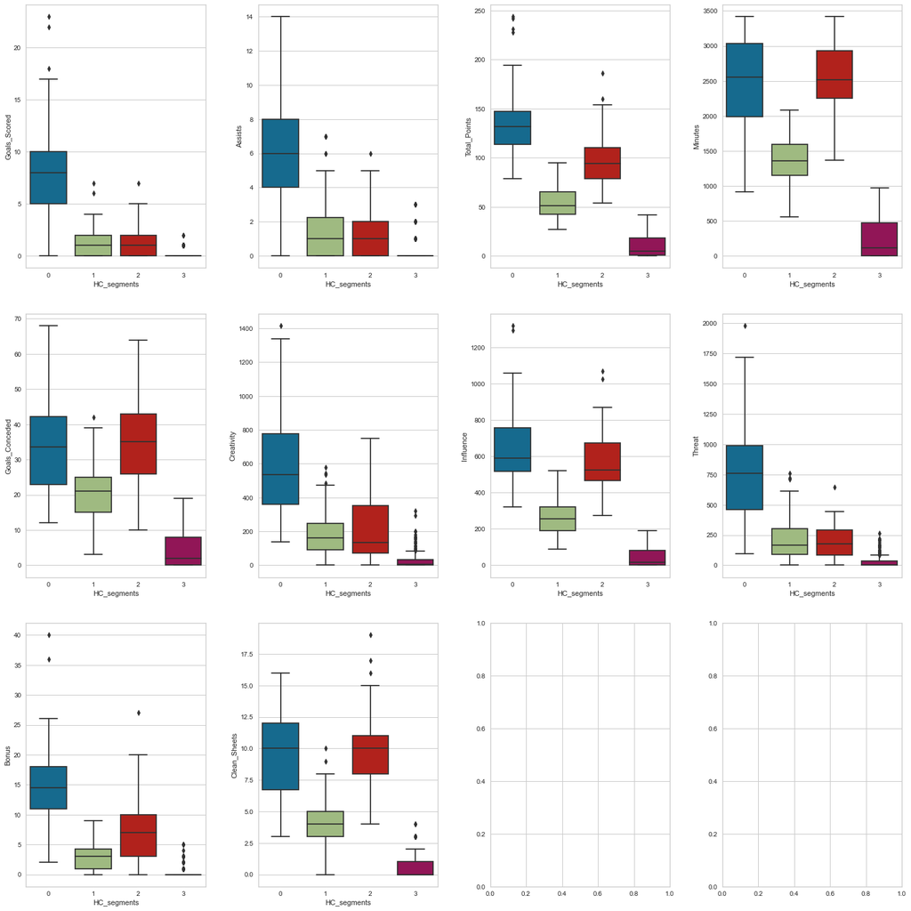

```python
fig, axes = plt.subplots(3, 4, figsize=(20, 20))
counter = 0

for ii in range(3):
    for jj in range(4):
        if counter < 10:
            sns.boxplot(
                ax=axes[ii][jj],
                data=df2,
                y=df2.columns[3+counter],
                x="HC_segments",
            )
            counter = counter + 1

fig.tight_layout(pad=3.0)
```

## K-means vs Hierarchical Clustering

- Only cluster 3 in both segments had similar compositions
- Some players were swapped between the clusters obtained using both techniques.
- Although scores are similar for the equivalent cluster in each method used, the composition of clusters 0 , 1 and 2 are different when K-Means is Compared to Hierarchical
- The sklearn implementations of both the techniques take nearly the same amount of time to execute. However, dendrograms in Hierarchical clustering take more time to render.

**We will move ahead with the clusters obtained using Hierarchical clustering.**

```python
hc_cluster_profile.style.highlight_max(color="lightgreen", axis=0)
```

| HC_segments | Goals_Scored | Assists | Total_Points | Minutes | Goals_Conceded | Creativity | Influence | Threat | Bonus | Clean_Sheets | count_in_each_segment |
| --- | --- | --- | --- | --- | --- | --- | --- | --- | --- | --- | --- |
| 0 | 7.960526 | 6.342105 | 135.592105 | 2467.605263 | 33.802632 | 594.343421 | 638.431579 | 772.302632 | 14.736842 | 9.302632 | 76 |
| 1 | 1.357143 | 1.669643 | 53.812500 | 1367.767857 | 20.866071 | 186.037500 | 259.967857 | 218.866071 | 3.000000 | 4.437500 | 112 |
| 2 | 1.247423 | 1.206186 | 98.453608 | 2557.814433 | 35.371134 | 220.125773 | 556.723711 | 185.505155 | 7.237113 | 9.721649 | 97 |
| 3 | 0.157068 | 0.251309 | 10.324607 | 248.863874 | 4.094241 | 31.026702 | 45.018848 | 30.785340 | 0.460733 | 0.586387 | 191 |

```python
df2.groupby(["HC_segments", "Position"])['Player_Name'].count()
```

```
HC_segments  Position
0            Defender      10
             Forward       21
             Midfielder    45
1            Defender      38
             Forward       14
             Goalkeeper     3
             Midfielder    57
2            Defender      52
             Goalkeeper    17
             Midfielder    28
3            Defender      72
             Forward       29
             Goalkeeper    25
             Midfielder    65
Name: Player_Name, dtype: int64
```

## Actionable Insights and Recommendations

**Cluster 0**

- There are `76` players in this cluster.
- This appears to be the `top-ranking group` in terms of (Creativity, Influence, Threat, Bonus)
- This group scored the highest Total points of 136,
- On average the players scored 8 goals, 6 assists.
- Creativity 594, Influence 638 and Threat 772 Points are highest
- This group conceded the second highest number of goals on average at 34
- On average they played 9 games since they last conceded a goal

**Cluster 1**

- There are `112` players in this cluster.
- This appears to be the `third ranking group` in terms of (Creativity, Influence, Threat, Bonus)
- This group scored the third highest Total points of 54,
- On average the players scored 1 goal and 2 assist.
- This group conceded the third highest number of goals on average at 20
- On average they played 4 games since they last conceded a goal

**Cluster 2**

- There are `97` players in this cluster.
- This appears to be the `second ranking group` in terms of (Creativity, Influence, Threat, Bonus)
- This group scored second highest Total points of 98
- Players score on average 1 goals, 1 assist.
- This group conceded the highest number of goals on average at 35
- On average they played 10 games since they last conceded a goal

**Cluster 3**

- There are `191` players in this cluster.
- This appears to be the `lowest ranking group` in terms of (Creativity, Influence, Threat, Bonus)
- This group scored the lowest Total points of 10
- Players score on no goals or assists.
- This group conceded the least number of goals on average at 4
- On average they played 1 game since they last conceded a goal

## Add-on: PCA for visualization

- Let's use PCA to reduce the data to two dimensions and visualize it to see how well-separated the clusters are.

```python
from sklearn.decomposition import PCA

pca = PCA(n_components=2)
X_reduced_pca = pca.fit_transform(subset_scaled_df)

# storing results in a dataframe
reduced_data_df_pca = pd.DataFrame(data = X_reduced_pca, columns = ['Component 1', 'Component 2'])

# checking the amount of variance explained
print(f'The first two principal components explain {np.round(100*pca.explained_variance_ratio_.sum(), 2)}% of the variance in the data.')
```

```
The first two principal components explain 85.81% of the variance in the data.
```

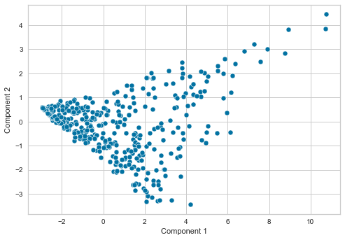

```python
sns.scatterplot(data=reduced_data_df_pca, x='Component 1', y='Component 2')
```

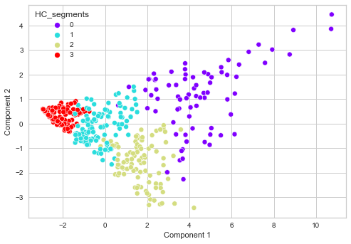

```python
sns.scatterplot(data=reduced_data_df_pca, x='Component 1', y='Component 2', hue=df2["HC_segments"], palette='rainbow')
```

**Observations**

- The clusters are well separated
- The HC segments are reliable to use for determining the price of the various players.